# rMetabolomics - an R Project for Data Processing and Statistical Analysis of Metabolomics Datasets

Sayed Metwaly MD, MSc, PhD student

March 18, 2017

# Introduction

### What and Why?

**rMetabolomics** is an R Markdown project I made specifically to perform data processing and statistical analysis of metabolomics data. Most of the popular statistical software packages perform data procssing/analysis on a single metabolite at a time with limited capability to do batch processing/analysis thus they are of limited benefit when handling metabolomics data. There are some online tools dedicated for the purpose of metabolomics data analysis but issues with internet connectivity and service run down during  
maintenance times limit their reliability.

### Requirements

I programmed **rMetabolomics** to be fully automated, the only required input is the name of the dataset file. Right now only CSV files are accepted. Dataset must comply with the generally accepted metabolomics data configuration: metabolites in columns, samples in rows and first 2 columns contain sample ID and class respectively. Currently rMetabolomics can process 2 classes only (e.g. disease vs control, survivors vs non- survivors … etc.).

### Structure

The code of **rMetabolomics** is organized in 3 parts: starting, data processing and data analysis. Each part is composed of sections called “modules” which carry out specific tasks. Modules are connected and depend on each other. I added comments to explain what is the task of the module and how the code works.

### Future plans

I am planning to include analysis of variance (ANOVA), principal component analysis (PCA), partial least square discriminant analysis (PLS-DA) and orthogonal partial least square discriminant analysis (oPLS-DA) are in future versions of rMetabolomics. Importantly, I am planning to make next versions able to automatically run the optimal statistical test based on the data entered.

# Part1: Let’s get started!

This part does initialization and loads necessary custom functions.

### 1.1 Initialization module

Here we specify the dataset file. This module does not produce any output, it just loads the dataset and required packages.

```r
#Initialization Module: loads dataset and the required packages.

#Clear R environment.
rm(list=ls(all=TRUE))

#load the dataset from a csv file.
#Note: CSV file layout must comply with generally acceptable metabolomics dataset structure (1st column: samples ID, 2nd column: class/sample type, samples in rows and metabolites in columns)
rawDataset <-read.csv("C:/Users/metwa/Medicine/Study/Canada/Calgary/Courses, Workshops, Seminars/11 R Wizardry/Final Project/example_dataset_oxylipins_raw.csv", header=TRUE, sep=",", check.names=FALSE, stringsAsFactors=TRUE, comment.char="")

#Load required packages
library("ggplot2")
library("reshape2")
library("plyr")
library("scales")
library("gridExtra")
library("grid")
library("gtable")
library("pwr")
library("plot3D")
library("rgl")
library("plot3Drgl")
```

### 1.2 Graphics module

This module contains 3 custom made graphics functions (matrixPlot, matrixCompare and drawTable). Functions in this modules are used throughout the rest of rMetabolomics.

```r
#Graphics module contains custom  plotting functions used throughout the project.


#-------------------------------------------Function matrixPlot-----------------------------------------------
# Custom function to do boxploting for an entire matrix
# Inputs: numeric matrix, title, x axis label, y axis label,boxplot orientation
matrixPlot<-function(data_mat , title="",x_lab="", y_lab="" , boxplot_orient="v" ){


meltData <- melt(data_mat) #converts data_mat into long format
x<-factor(meltData[,2])
y<-meltData[,3]

p <- ggplot(meltData, aes(x,y, fill=x ))#Initialize the plot


if (boxplot_orient=="h") { #Horizontal orientation of boxplots
  p + geom_boxplot(color="black",position = "dodge" )+
  coord_flip()+
  theme(legend.position="none", axis.ticks = element_blank(), axis.text.x = element_blank(), axis.text.y  = element_text(angle=0, vjust=0.5, size=6,face="bold"))+
  labs(title=title,x=x_lab, y = y_lab)

} else { #Vertical orientation of boxplots
 p + geom_boxplot(color="black",position = "dodge" )+
  theme(legend.position="none", axis.ticks = element_blank(), axis.text.y = element_blank(), axis.text.x  = element_text(angle=90, hjust=0.5, size=6,face="bold"))+
  labs(title=title,x=x_lab, y = y_lab)
}

}#------------------------------------------------------------------------------------------------------------


#-------------------------------------------Function matrixCompare--------------------------------------------
# Custom function to compare an the mean value of 2 matrices
# Inputs: 2 numeric matrices, 2 titles
matrixCompare<-function(mat1 , mat2, mat1_title="",mat2_title="" ){

# set graphics window to plot side by side
layout(matrix(c(1,1,2,2), 2, 2, byrow = TRUE))
par(mfrow = c(1,2), mai=c(1,1,1,0))

#replace all non-numeric data with 0
mat1[which(is.numeric(mat1)==FALSE)] <- 0
mat2[which(is.numeric(mat2)==FALSE)] <- 0

#Plot the denisty of the mean of each column (metabolite) for the 2 numeric matrices
plot(density(apply(mat1, 2, mean), na.rm = TRUE), main=mat1_title)
plot(density(apply(mat2, 2, mean), na.rm = TRUE), main=mat2_title)

}#------------------------------------------------------------------------------------------------------------



#-------------------------------------------Function drawTable------------------------------------------------
# Custom function to draw graphic tables
# Inputs: matrix, title, footer, title text size, footer font face
drawTable<-function(d , title_txt="", footer_txt="", title_txt_size=20,footer_fontface="plain" ){

table <- tableGrob(d) #Initialize the table

#Initialize table title and footer
title <- textGrob(title_txt,gp=gpar(fontsize=title_txt_size))
footnote <- textGrob(footer_txt, x=0, hjust=0,
                     gp=gpar( fontface=footer_fontface))

padding <- unit(1,"line")#Sets the distance between elements

#Draw table + title
table <- gtable_add_rows(table,
                         heights = grobHeight(title) + padding,
                         pos = 0)
#Adds footnote
table <- gtable_add_rows(table,
                         heights = grobHeight(footnote)+ padding)

#Sets the alignment of title and footer
table <- gtable_add_grob(table, list(title, footnote),
                         t=c(1, nrow(table)), l=c(1,1),
                         r=ncol(table))

#Plot the complete table
grid.newpage()
grid.draw(table)
}#------------------------------------------------------------------------------------------------------------
```

# Part2: Data Processing

Data processing consists of plotting, normalization, transformation and scaling of data.

### 2.1 Plot Raw Data

After entering the dataset file name rMetabolomics will Load dataset and plot raw data.

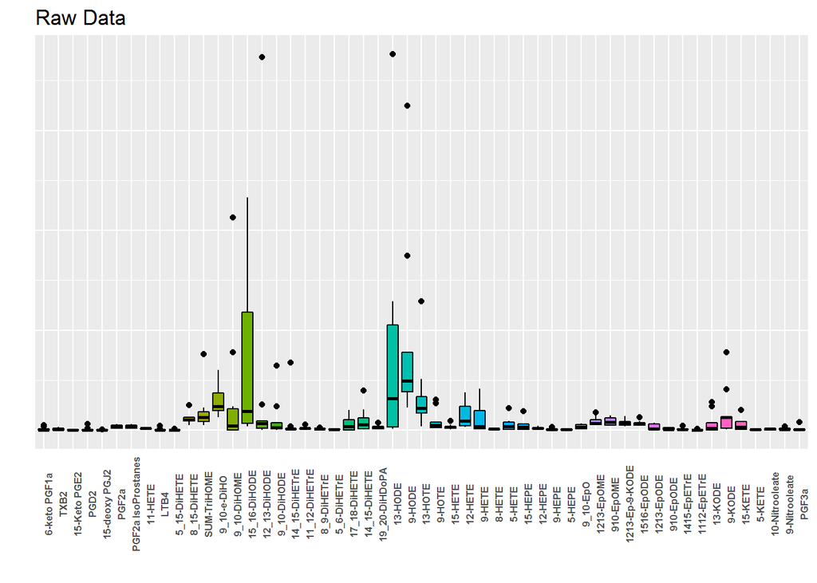

```r
numericData<-data.matrix(rawDataset[,3:ncol(rawDataset)]) #Excludes the primary ID and sample type columns

matrixPlot(data_mat=numericData , title="Raw Data",x_lab="", y_lab="" , boxplot_orient="v")#Plot the numeric data
```

### 2.2 Normalization

Typically metabolomics samples show high variability in concentration, and the derived metabolic profiles have a heteroscedastic noise structure characterized by increasing variance as a function of increased signal intensity. These sources of experimental and instrumental noise substantially complicate information recovery when statistical tools are used. Median fold change normalization is least compromised by the biologically relevant changes in mixture components and is thus preferable normalization method.

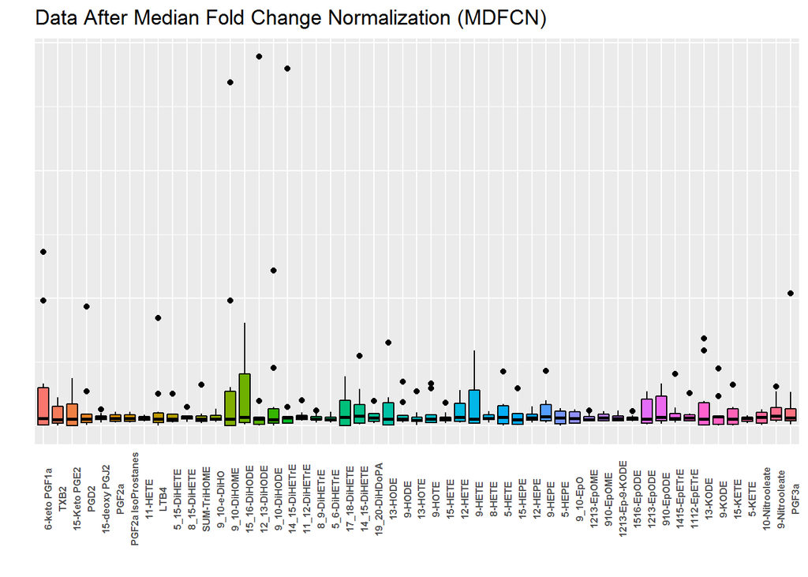

```r
#-------------------------------------------Function MDFCN----------------------------------------------------
# Custom function to perform median fold change normalisation
# Inputs: numeric matrix
# Priniple: calculates median of the rows --> divide each cell by its row median --> calcuate columns median --> divide each cell by the column median

MDFCN <- function(mat) {

  #Replace any non-numeric values in the dataset with 0
  mat[which(is.numeric(mat)==FALSE)] <- 0

  #Calculates median of the rows of the input matrix and store them in the vector medSam
  medSam <- apply(mat, 1, median)
  medSam[which(medSam==0)] <- 0.0001 #Replace any median 0 with 0.0001 (to avoid divide by zero later on)

  #Divide cells by the its respective row median, calculates  columns median and divide each cell by the column median
  mat <- apply(mat, 2, function(mat, medSam){
    medFDiSmpl <- mat/medSam
    vec<-mat/median(medFDiSmpl)
    return(vec)
  }, medSam)

  return (mat)
}#------------------------------------------------------------------------------------------------------------

numericData.normalized<-MDFCN(numericData) #Call MDFCN function to normalize numericData

#Plot the normalized data
matrixPlot(data_mat=numericData.normalized , title="Data After Median Fold Change Normalization (MDFCN)",x_lab="", y_lab="" , boxplot_orient="v")
```

### 2.3 Data Transformation

Logarithmic transformation of data is usually required given the highly skewed nature of the metabolomics results. **rMetabolomics** will do base 10 logarithmic transformation and plot transformed data.

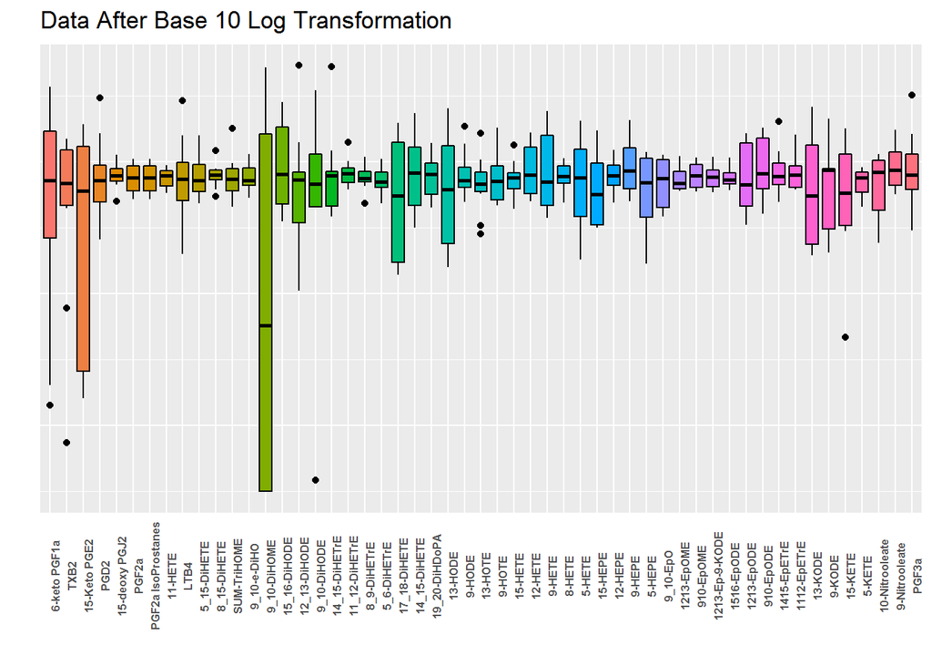

```r
numericData.log<-log10(numericData.normalized)#perform log transformation to the data

#plot the transformed data
matrixPlot(data_mat=numericData.log , title="Data After Base 10 Log Transformation",x_lab="", y_lab="" , boxplot_orient="v")
```

### 2.4 Data Scaling

Data scaling aims to centralize the data based on the mean of each metabolite. It is commonly the final step in data processing before statistical analysis is performed. **rMetabolomics** will do z scaling and plot scaled data.

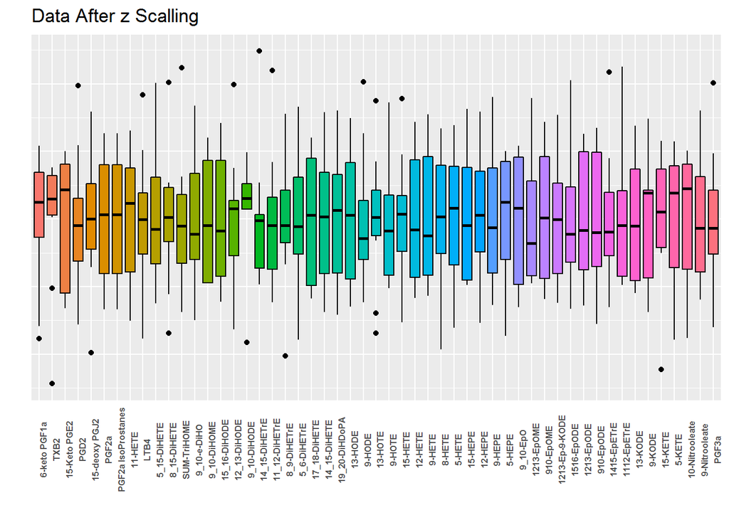

```r
#----------------------------------------------Function zScale------------------------------------------------
# Calculates z_score, formula: (x-u)/sd
# inputs: a numeric matrix
zScale<-function (num_mat){

  #Replace any non-numeric values in the dataset with 0
  num_mat[which(is.numeric(num_mat)==FALSE)] <- 0


  #Subtracts the column mean from each cell and divide the result by the column sd
  num_mat <- apply(num_mat, 2, function(num_mat){

  #Calculates mean of the columns of the input matrix and store them in the vector meanCol
  meanCol<-mean(num_mat)

  #Calculates sd of the columns of the input matrix and store them in the vector sdCol
  sdCol <- sd(num_mat)
  sdCol[which(sdCol==0)] <- 0.0001 #Replace any mean 0 with 0.0001 (to avoid divide by zero later on)

    num_mat <- num_mat-meanCol
    num_mat<-num_mat/sdCol
    return(num_mat)
  })

return(num_mat)
}#------------------------------------------------------------------------------------------------------------

numericData.z<-zScale(numericData.log)#Call zScale function to normalize numericData.log

#Plot z-scaled data
matrixPlot(data_mat=numericData.z , title="Data After z Scalling",x_lab="", y_lab="" , boxplot_orient="v")
```

```r
processedDataset <- cbind(rawDataset[,1:2],numericData.z)#saves the final processed data: composed of first 2 columns of the raw data (sample ID and Class) and processed numeric matrix
```

### 2.5 Data Processing Summary

As a final step in data processing, **rMetabolomics** will provide an overal visual reprsentation of the data before and after processing.

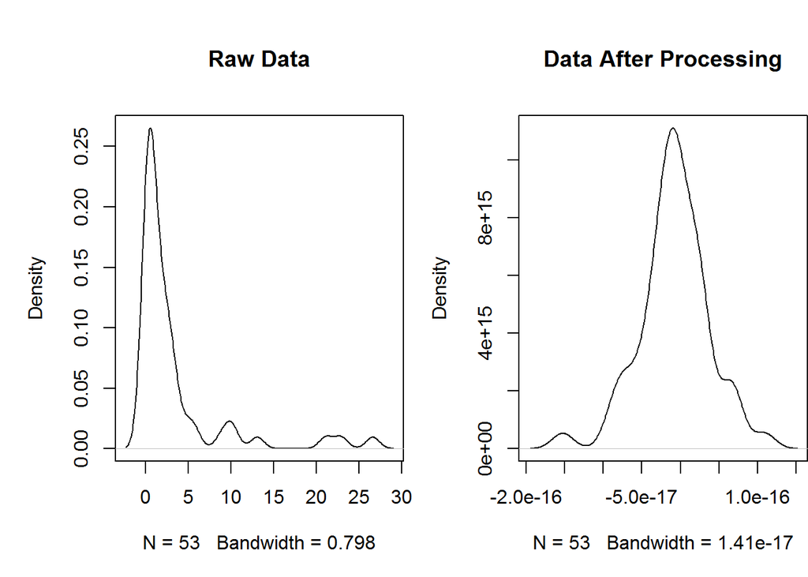

```r
#Calls matrixCompare function to compare between raw data and processed data
matrixCompare(numericData , numericData.z, mat1_title="Raw Data",mat2_title="Data After Processing" )
```

# Part3: Statistical Analysis

In this part **rMetabolomics** will do univariate statistical analysis of the processed data. Analysis consists of doing correlation matrix, heatmap, t-test, sample size calculation and **“Power Array”**

### 3.1 Correlation Matrix

Correlation matrix provides an overview of the correlation between all metabolites. Spearman correlation is preferentially selected given the skewed nature of most metabolomics data. I programmed **rMetabolomics** to automatically do a correlation matrix (Spearman correlation) for all metabolites and plot the result.

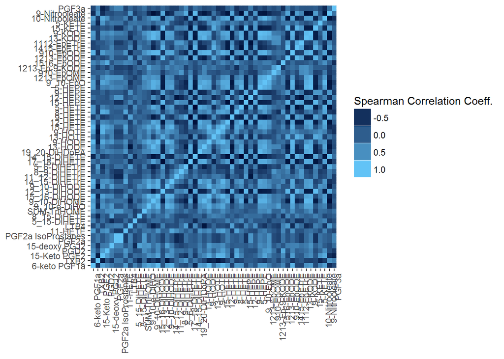

```r
#----------------------------------------Function corSpearman--------------------------------------------------
#Plots a Spearman Correlation Matrix using using qplot
#Inputs: processed numeric data matrix (normalized, transformed and scaled data)
corSpearman<-function (processed_mat){

#perform spearman correlation and convert the output matrix into the long format
data=melt(cor(processed_mat, method="spearman"))

#Plots the output matrix
qplot(x=data[,1], y=data[,2], data=data, fill=value, geom="tile") +
  theme(axis.text.x = element_text(angle = 90, hjust = 1))+ theme(axis.title.x=element_blank(), axis.title.y=element_blank())+
  scale_fill_gradient(low="#000433", high="#62c3f6")+
  guides(fill = guide_legend(title = "Spearman Correlation Coeff." ))
}#-------------------------------------------------------------------------------------------------------------

corSpearman(numericData.z)
```

### 3.2 Heatmap

Heatmap provides an intuitive way to evaluate the dataset. I programmed **rMetabolomics** to rearrange the samples based on the sample type/class. Then sample type indicator is plotted in the first column of the heatmap. As a general rule, the more a metabolite column shows agreement with the first column (sample type indicator) in the heatmap, the more it can be used to separate between sample classes.

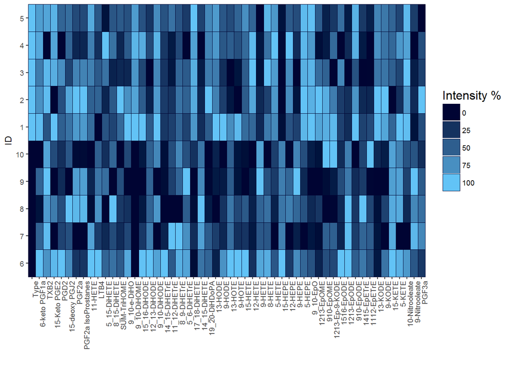

```r
#-----------------------------------------------Function ggHeatmap--------------------------------------------
#Plots a heatmap of the dataset
#Inputs: processed numeric data matrix (normalized, transformed and scaled data)
ggHeatmap<-function (processed_dataset){

gg_heatmap_mat<-processed_dataset
gg_heatmap_mat[,2]<-as.numeric(as.factor(gg_heatmap_mat[,2]))#convert sample type into factor then into number

#Arranges sample ID by the class/sample type and plots arranged sample IDs on Y axis
gg_heatmap_mat[,1]<- reorder(gg_heatmap_mat[,1],gg_heatmap_mat[,2])

gg_heatmap_mat.melt <- melt(gg_heatmap_mat)#converts it into long format

#Rescale all variable (columns) values in the output matrix so that they lie between 0-100
gg_heatmap_mat.melt <- ddply(gg_heatmap_mat.melt, .(variable), transform,rescale = rescale(value, to=c(0,100)))

#Plot the result using geom_tile
(p <- ggplot(gg_heatmap_mat.melt, aes(variable, gg_heatmap_mat.melt[,1])) +
    geom_tile(aes(fill = rescale),colour = "#000433") +
    scale_fill_gradient(low = "#000433", high = "#62c3f6"))#sets the gradient colour range
base_size <- 9
p + theme_grey(base_size = base_size) +
  labs(x = "", y = colnames(gg_heatmap_mat)[1]) +
  scale_x_discrete(expand = c(0, 0)) +
  scale_y_discrete(expand = c(0, 0)) +
  theme( axis.text.x = element_text(size = base_size * 0.8, angle = 90, hjust = 1))+
  guides(fill =
           guide_legend(title = "Intensity %",#the title of the legend
             title.theme = element_text(
               angle = 0
             )
           )
  )


}#-------------------------------------------------------------------------------------------------------------

ggHeatmap(processedDataset)
```

### 3.3 Statistical Significance Test (t-test)

Next I programmed **rMetabolomics** to do a series of 2 sample t-tests comparing the levels of each metabolite in both classes, perform Bonferroni adjustment of p-values for family wise error rate FWER correction, plot significant metabolites and prints a table with the details.

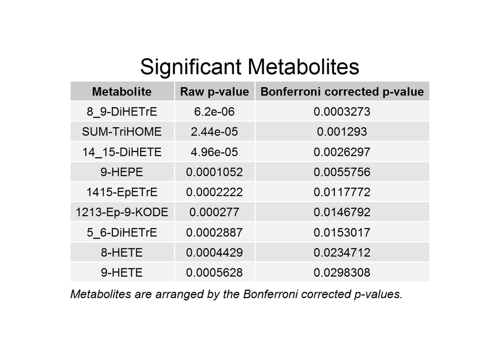

```r
#Work on the processed dataset (though it converts any non-numeric data into 0)
dat<-processedDataset
dat[which(is.numeric(dat)==FALSE)] <- 0

iniFlag<-FALSE #Flip-flop logical flag to mark the first time a condition occurs ;-))
for (metaCounter in 3:ncol(dat)){ #Here the loop starts from the 3rd column of the data (to avoid working on sample ID or class values)
#A saftey condition to run t-test calculation only if the column does not contain NaN or NA
if (is.nan(sum(dat[,metaCounter]))==FALSE & is.na(sum(dat[,metaCounter]))==FALSE){
t.table<-t.test(dat[,metaCounter] ~ dat[,2], data=dat[,c(2,metaCounter)])#performs t-test on column metaCounter of data (contains the metabolite values) by the group in column 2 (contains sample type/classes)
pval<-t.table$p.value
}else{pval<-1}#If we encounter NaN or NA -> set p-value to 1
      if (iniFlag==FALSE){iniFlag<-TRUE;  raw_p_value.list<-c(pval)}else{
       raw_p_value.list<-c(raw_p_value.list, pval)#saves the raw p-values for all metabolites

    }

}


#applies Bonferroni family wise error rate FWER correction for multiple comparisons
bonf_p_value.list<-p.adjust(raw_p_value.list, method = "bonferroni", n = length(raw_p_value.list))


iniFlag<-FALSE #Flip-flop logical flag to mark the first time a condition occurs ;-))
for (metaCounter in 1:length(bonf_p_value.list)){

    if (bonf_p_value.list[metaCounter]<0.05){#select adjusted p-value <0.05 (significant p-values)
      if (iniFlag==FALSE){iniFlag<-TRUE;  sig.list<-c(metaCounter)}else{
       sig.list<-c(sig.list, metaCounter)#saves the positions of significant p-values after Bonferroni correction

      }
    }

}


dataSubset<-matrix(rep(0,length(sig.list)*3), nrow=length(sig.list),ncol=3)#Initialize matrix
dataSubset[,1]<-colnames(dat)[sig.list]#Retrive names of significant metabolites
dataSubset[,2]<-round(raw_p_value.list[sig.list],7)#Retrive raw p-value of significant metabolites
dataSubset[,3]<-round(bonf_p_value.list[sig.list],7)#Retrive adjusted p-value of significant metabolites
colnames(dataSubset)<-c("Metabolite","Raw p-value","Bonferroni corrected p-value")

#calls darwTable to draw a table of the rearranged the matrix (by the values of the Bonferroni corrected p-values)
drawTable(dataSubset[order(as.numeric(dataSubset[,3])),] , title_txt="Significant Metabolites", footer_txt="Metabolites are arranged by the Bonferroni corrected p-values.", title_txt_size=22,footer_fontface="italic" )
```

```r
#Retrives the columns of significant metabolites + the sample class
dataSubset<-melt(dat[,c(2,sig.list)])
```

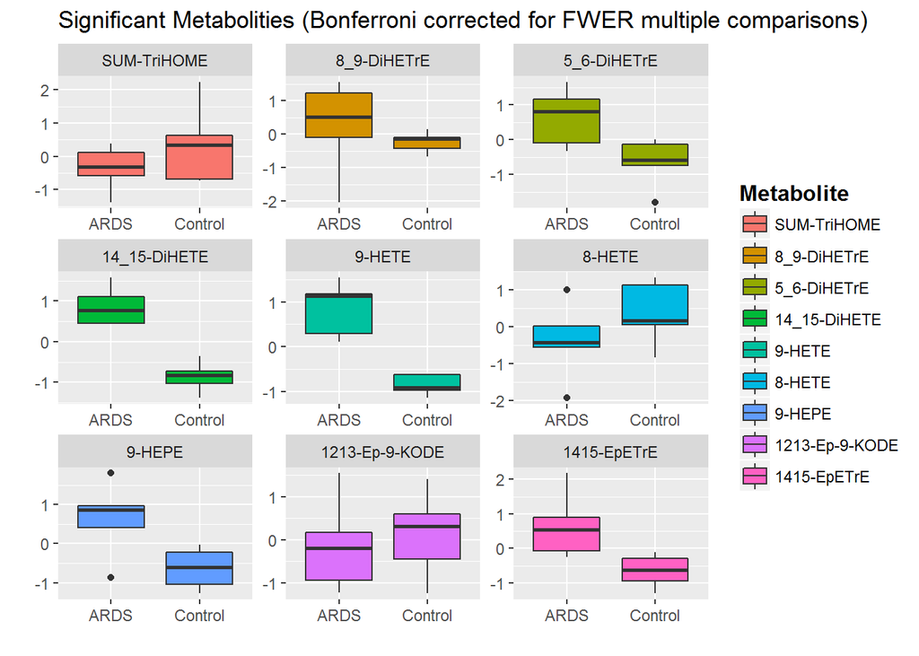

```r
#Plots boxplots of the significant metabolites comparing the level of metabolite between the classes
ggplot(dataSubset, aes(dataSubset[,1], dataSubset[,3], fill=dataSubset[,2]))+
ggtitle("Significant Metabolities (Bonferroni corrected for FWER multiple comparisons)") +
geom_boxplot() +
facet_wrap(~dataSubset[,2], scales="free")+
  labs(x="", y="")+
  guides(fill =
           guide_legend(title = "Metabolite",
             title.theme = element_text(
               face = "bold",
               angle = 0
             )
           )
         )
```

### 3.4 Sample Size Calculation

Next **rMetabolomics** will Calculate required sample size (n) per group for the previously identified significant metabolites. I programmed **rMetabolomics** to calculate sample size using the widely acceptable standards: significance level (alpha) = 0.05, power = 80%.

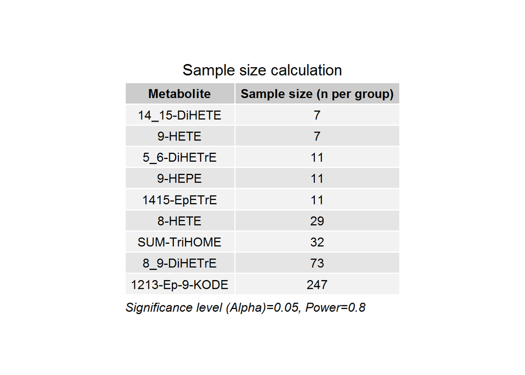

```r
#Define the input data, significance level and power
dat<-processedDataset
alpha_level=0.05
power_level=0.80


dataSubset<-dat[,c(2,sig.list)]#retrives only the significant metabolites

class1<-levels(dataSubset[,1])[1]#Gets the 1st class name (1st level in the sample type/class cloumn)
class2<-levels(dataSubset[,1])[2]#Gets the 2st class name (2nd level in the sample type/class cloumn)

iniFlag<-FALSE #Flip-flop logical flag to mark the first time a condition occurs ;-))
for (metaCounter in 2:ncol(dataSubset)){ #a loop to calculate mean delta, sd and sample size for each metabolite
       means_delta<-mean(dataSubset[dataSubset[,1]==class1, metaCounter])-mean(dataSubset[dataSubset[,1]==class2, metaCounter])
       col_sd<-sd(dataSubset[, metaCounter])
       power_t <- power.t.test(n = NULL, sd = col_sd, delta = means_delta, sig.level=alpha_level, power = power_level, type="two.sample", alternative = "two.sided")
       if (iniFlag==FALSE){
         iniFlag<-TRUE
         n.list<-c(round_any(power_t$n,1, f = ceiling)) #round sample size to the upper value to be statistically more conservative ;-))
         sd_list<-c(col_sd)
         delta_list<-c(means_delta)

       }else{

         n.list<-c(n.list, round_any(power_t$n,1, f = ceiling))#round sample size to the upper value to be statistically more conservative ;-))
         sd_list<-c(sd_list, col_sd)
         delta_list<-c(delta_list, means_delta)

      }

}


dataSubset<-matrix(rep(0,length(sig.list)*5), nrow=length(sig.list),ncol=5)#initialize dataSubset
dataSubset[,1]<-colnames(dat)[sig.list]#gets the names of significant metabolites
dataSubset[,2]<-n.list #list of sample sizes
dataSubset[,3]<-sig.list #positions of significant metabolites
dataSubset[,4]<-sd_list #list of sd
dataSubset[,5]<-delta_list #list of mean delta
colnames(dataSubset)<-c("Metabolite","Sample size (n per group)","","","")

#rearrange the matrix by the n size (ascending order ie from the smallest sample size to the greatest)
dataSubset<-dataSubset[order(as.numeric(dataSubset[,2])),]

#Calls drawTable to draw a table of the 1st and 2d columns only (metabolites name and n)
drawTable( dataSubset[,1:2], title_txt="Sample size calculation", footer_txt=paste("Significance level (Alpha)=",alpha_level,", Power=",power_level, sep=""), title_txt_size=15,footer_fontface="italic" )
```

```r
#rearrange the matrix by the n size - this time in descending order (just for the sake of a better looking 3D plot next ;-))
dataSubset<-dataSubset[order(-as.numeric(dataSubset[,2])),]
sig.list.arranged<-as.numeric(dataSubset[,3])
sd_list.arranged<-as.numeric(dataSubset[,4])
delta_list.arranged<-as.numeric(dataSubset[,5])
```

### 3.5 Power Array **(Interactive 3D Model)**

Finally I programmed **rMetabolomics** to plot an innovative **“Power Array”** which is an interactive 3D model. Power Array shows the statistical power obtained for each significant metabolites at a set of fixed sample sizes (n of 3,6,10,16,24,40,60,100,150 and 200). Its aim is to help researchers decide the final sample size and metabolites to be used in further studies in an easy intuitive way. Power Array 3D model can be manipulated by the computer mouse.

```r
testN<-c(3,6,10,16,24,40,60,100,150,200)# sets fixed sample sizes at which we will compare the power of significant metabolites
dataSubset<-matrix(rep(0,length(sig.list.arranged)*10), nrow=length(sig.list.arranged),ncol=10)#initialize matrix
rownames(dataSubset)<-colnames(dat)[sig.list.arranged]# get names of the significant metabolites
colnames(dataSubset)<-testN

#A nested loop to cycle through the significant metabolites and perform power calculation at the preset fixed sample sizes selected above
for (metaCounter in 1:length(sig.list.arranged)){
  for (pwrlvlCounter in 1: length(testN)){
          power_t <- power.t.test(n = testN[pwrlvlCounter], sd = sd_list.arranged[metaCounter], delta = delta_list.arranged[metaCounter], sig.level=alpha_level, power = NULL, type="two.sample", alternative = "two.sided")

       dataSubset[metaCounter,pwrlvlCounter ] <-  power_t$power #save the power values to the dataSubset (these are the z values of the 3D bars)
  }
}

#set the initial details
nClmns<-ncol(dataSubset)
nRws<-nrow(dataSubset)
x_label="Metabolomics Technique"
y_label="N patients per group"
z_label="Power"
grphTitle="Power Array (Interactive 3D Model)"

# Create a function interpolating colors in the range of specified colors
jet.colors <- colorRampPalette( c("red",  "orange","yellow" ,"green4") )
# Generate the desired number of colors from this palette
nbcol <- 100
color <- jet.colors(nbcol)


        #Plot graphics
  hist3D (x = 1:nRws, y = 1:nClmns, z = dataSubset,
            bty = "g", phi = 20,  theta = -60,
            xlab = x_label, ylab = y_label, zlab = z_label, main = grphTitle,
            col=color, border = "black", shade = 0.8,box=FALSE,  axes = FALSE,
            ticktype = "detailed", space = 0.15, d = 2, cex.axis = 1e-9, add=FALSE, plot = FALSE)

    # Use text3D to label x axis
  text3D(x = 1:nRws, y = rep(-1, nRws), z = rep(0, nRws),
            labels = rownames(dataSubset),
            add = TRUE, adj = 1, plot = FALSE)
    # Use text3D to label y axis
  text3D(x = rep(0.5, nClmns),   y = 1:nClmns, z = rep(0, nClmns),
            labels  = colnames(dataSubset),
            add = TRUE, adj = 1, plot = FALSE)

    #Use RGL to create an interactive plot ;-)))
  plotrgl (smooth = TRUE, x = 1:nRws, y = 1:nClmns, z = dataSubset,
            bty = "g", phi = 20,  theta = -60,expand = 0.1,
            xlab = "", ylab = "", zlab = "", main = grphTitle,
            col = color, border = "black", shade = 0.4,box=TRUE, axes = FALSE,
            ticktype = "detailed", space = 0.9, d = 2, cex.axis = 1e-9)


    #put Z axiz scale
    axes3d( edges=c("z") )



#That is it, Thank you ;-))))
```

[interactive chart not shown]

# I used the following R libraries to program rMetabolomics:

ggplot2  
reshape2  
plyr  
scales  
gridExtra  
grid  
gtable  
pwr  
plot3D  
rgl  
plot3Drgl